# Black Assault death trends analysis

Jon Minton

3 May 2016

## Introduction

This document will present a series of analyses relating to assault/homicide related death trends in young adult Black Non-Hispanic (BNH) males.

To start with, I will load various dependencies and set various options that allow existing R stripts to be rendered as a PDF document.

Now to start to load and filter the data:

```r
dta <-  read_csv("data/tidied/icd_8_to_10_8fold.csv")

dta
```

```
## Source: local data frame [30,144 x 8]
##
##    icd_class  year   age    sex  race
##        (chr) (int) (chr)  (chr) (chr)
## 1     icd_08  1968   < 1 female black
## 2     icd_08  1968   < 1 female black
## 3     icd_08  1968   < 1 female black
## 4     icd_08  1968   < 1 female black
## 5     icd_08  1968   < 1 female black
## 6     icd_08  1968   < 1 female black
## 7     icd_08  1968   < 1 female black
## 8     icd_08  1968   < 1 female black
## 9     icd_08  1968   1-4 female black
## 10    icd_08  1968   1-4 female black
## ..       ...   ...   ...    ...   ...
## Variables not shown: cause (chr), death_count (int), population_count
##   (dbl)
```

```r
# Which age groups for which years?
dta %>% xtabs(~ year + age, data = .)
```

```
##       age
## year   < 1 1-4 10-14 15-19 20-24 25-34 35-44 45-54 5-9 55-64 65-74 75-84
##   1968  48  48    48    48    48    48    48    48  48    48    48    48
##   1969  48  48    48    48    48    48    48    48  48    48    48    48
##   1970  48  48    48    48    48    48    48    48  48    48    48    48
##   1971  48  48    48    48    48    48    48    48  48    48    48    48
##   1972  48  48    48    48    48    48    48    48  48    48    48    48
##   1973  48  48    48    48    48    48    48    48  48    48    48    48
##   1974  48  48    48    48    48    48    48    48  48    48    48    48
##   1975  48  48    48    48    48    48    48    48  48    48    48    48
##   1976  48  48    48    48    48    48    48    48  48    48    48    48
##   1977  48  48    48    48    48    48    48    48  48    48    48    48
##   1978  48  48    48    48    48    48    48    48  48    48    48    48
##   1979  48  48    48    48    48    48    48    48  48    48    48    48
##   1980  48  48    48    48    48    48    48    48  48    48    48    48
```

[output cut: 34 more lines]

```r
# What discrete types of death are available?

dta %>% group_by(cause) %>% tally
```

```
## Source: local data frame [8 x 2]
##
##                                   cause     n
##                                   (chr) (int)
## 1                             all_cause  3768
## 2                          all_external  3768
## 3                               assault  3768
## 4 intentional_or_undetermined_self_harm  3768
## 5                 intentional_self_harm  3768
## 6                          non_external  3768
## 7                          undetermined  3768
## 8                               vehicle  3768
```

We decided previously to look at the age group 15 to 34 years, to focus on BNH, and to look at deaths through assault and homicide. Additionally, we want to add a variable indicating for which years there was a Republican Presidency.

[output not shown]

Next, we produce another variant that allows the log mortality rate to vary as a function of time in years since each change in Presidency between parties, in a new dataframe called ‘knotted’

```r
dta_subset %>% mutate(
  k1970 = ifelse( year > 1970, year - 1970, 0), # JAVIER: IS THIS CORRECT?
  k1978 = ifelse( year > 1978, year - 1978, 0),
  k1982 = ifelse( year > 1982, year - 1982, 0),
  k1994 = ifelse( year > 1994, year - 1994, 0),
  k2002 = ifelse( year > 2002, year - 2002, 0),
  k2010 = ifelse( year > 2010, year - 2010, 0)
) %>%
  mutate(
    death_rate = death_count / population_count,
    lg10mr = log(death_rate, 10)
    ) -> knotted

knotted
```

```
## Source: local data frame [94 x 13]
## Groups: year [47]
##
##     year    sex death_count population_count   rep k1970 k1978 k1982 k1994
##    (int)  (chr)       (int)            (dbl) (dbl) (dbl) (dbl) (dbl) (dbl)
## 1   1968 female         710          3406000     1     0     0     0     0
## 2   1968   male        3217          3027000     1     0     0     0     0
## 3   1969 female         755          3538000     1     0     0     0     0
## 4   1969   male        3566          3153000     1     0     0     0     0
## 5   1970 female         760          3651372     0     0     0     0     0
## 6   1970   male        3900          3267088     0     0     0     0     0
## 7   1971 female         900          3840000     0     1     0     0     0
## 8   1971   male        4514          3468000     0     1     0     0     0
## 9   1972 female         956          4002000     0     2     0     0     0
## 10  1972   male        4750          3640000     0     2     0     0     0
## ..   ...    ...         ...              ...   ...   ...   ...   ...   ...
## Variables not shown: k2002 (dbl), k2010 (dbl), death_rate (dbl), lg10mr
##   (dbl)
```

## First analysis: model of log mort against knots

We first produce two separate models, one for each sex, of log mortality against the knots

```r
models <- dlply( # This code runs the model
  knotted,
  .(sex),
  function(x) lm(lg10mr ~ year + k1970 + k1978 + k1982 + k1994+ k2002+ k2010, data = x)
)

llply(models, summary) # This code prints the summary for each gender's model
```

```
## $female
##
## Call:
## lm(formula = lg10mr ~ year + k1970 + k1978 + k1982 + k1994 +
##     k2002 + k2010, data = x)
##
## Residuals:
##       Min        1Q    Median        3Q       Max
## -0.057364 -0.023080 -0.002725  0.016194  0.067359
##
## Coefficients:
##               Estimate Std. Error t value Pr(>|t|)
## (Intercept) -63.585285  39.904606  -1.593  0.11914
## year          0.030436   0.020263   1.502  0.14114
## k1970        -0.035382   0.022663  -1.561  0.12655
## k1978        -0.012739   0.009954  -1.280  0.20817
## k1982         0.023098   0.008270   2.793  0.00805 **
## k1994        -0.047528   0.004763  -9.979 2.72e-12 ***
## k2002         0.037737   0.006058   6.229 2.49e-07 ***
## k2010        -0.013505   0.011567  -1.168  0.25006
## ---
## Signif. codes:  0 '***' 0.001 '**' 0.01 '*' 0.05 '.' 0.1 ' ' 1
##
## Residual standard error: 0.03572 on 39 degrees of freedom
## Multiple R-squared:  0.9619, Adjusted R-squared:  0.9551
## F-statistic: 140.8 on 7 and 39 DF,  p-value: < 2.2e-16
##
##
## $male
##
## Call:
## lm(formula = lg10mr ~ year + k1970 + k1978 + k1982 + k1994 +
##     k2002 + k2010, data = x)
##
## Residuals:
##       Min        1Q    Median        3Q       Max
## -0.082860 -0.035583  0.004911  0.033209  0.084179
##
## Coefficients:
##               Estimate Std. Error t value Pr(>|t|)
## (Intercept) -9.416e+01  5.175e+01  -1.819 0.076540 .
## year         4.633e-02  2.628e-02   1.763 0.085735 .
## k1970       -6.140e-02  2.939e-02  -2.089 0.043271 *
## k1978       -3.581e-04  1.291e-02  -0.028 0.978010
## k1982        3.006e-02  1.073e-02   2.803 0.007853 **
## k1994       -4.030e-02  6.177e-03  -6.525  9.7e-08 ***
## k2002        2.803e-02  7.857e-03   3.568 0.000973 ***
## k2010       -2.146e-02  1.500e-02  -1.431 0.160458
## ---
## Signif. codes:  0 '***' 0.001 '**' 0.01 '*' 0.05 '.' 0.1 ' ' 1
##
## Residual standard error: 0.04632 on 39 degrees of freedom
## Multiple R-squared:  0.7436, Adjusted R-squared:  0.6976
## F-statistic: 16.16 on 7 and 39 DF,  p-value: 9.242e-10
```

We might also want to compare the fitted against the actual values

```r
tmp <- knotted %>%
  select(year, sex, actual = lg10mr)

tmp_female <- tmp %>% filter(sex == "female")
tmp_male <- tmp %>% filter(sex == "male")

tmp_female$fitted <- models[["female"]][["fitted.values"]]
tmp_male$fitted <- models[["male"]][["fitted.values"]]

fitted_actual_comparisons <- bind_rows(tmp_female, tmp_male)

rm(tmp, tmp_female, tmp_male)

fitted_actual_comparisons
```

```
## Source: local data frame [94 x 4]
##
##     year    sex    actual    fitted
##    (int)  (chr)     (dbl)     (dbl)
## 1   1968 female -3.680986 -3.687740
## 2   1969 female -3.670811 -3.657304
## 3   1970 female -3.681642 -3.626868
## 4   1971 female -3.630089 -3.631815
## 5   1972 female -3.621819 -3.636762
## 6   1973 female -3.603631 -3.641708
## 7   1974 female -3.593696 -3.646655
## 8   1975 female -3.634759 -3.651602
## 9   1976 female -3.676343 -3.656548
## 10  1977 female -3.684171 -3.661495
## ..   ...    ...       ...       ...
```

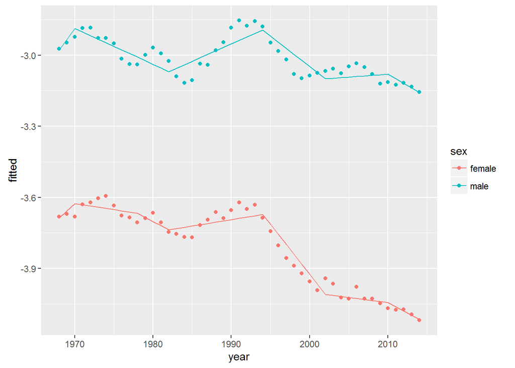

```r
fitted_actual_comparisons %>%
  ggplot(., aes(x = year, group = sex, colour = sex)) +
  geom_line(aes(y = fitted)) +
  geom_point(aes(y = actual))
```

## Additional (interrim) exercise: polynomials with year

As an interrim modelling analysis, here are some comparative model fits using different numbers of polynomial on year. These are compared using AIC and BIC.

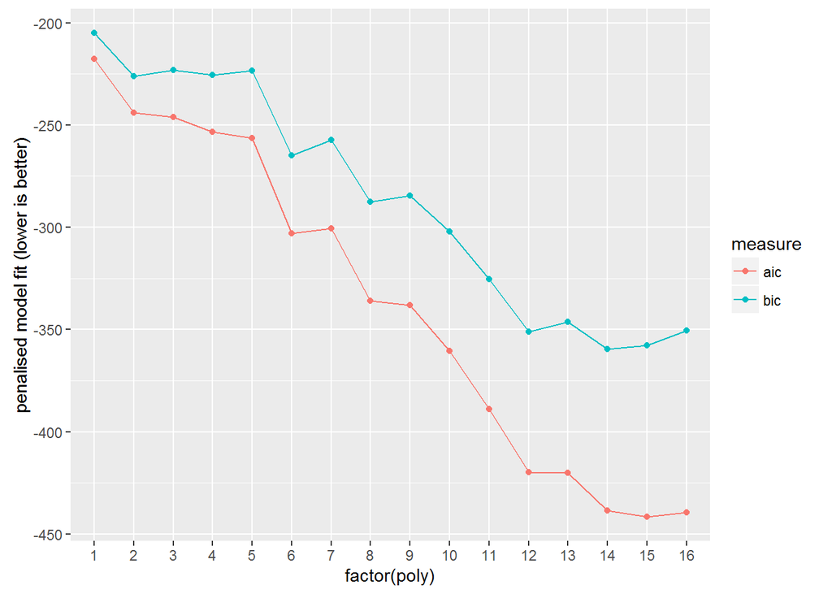

```r
simple <- knotted %>%
  select(year, sex, lg10mr) %>%
  ungroup %>%
  mutate(year2 = year - min(year)) # set to 1968 == 0

fn <- function(k){
  output <- lm(lg10mr ~ poly(year2, k) * sex, data = simple)
}

tmp <- llply(1:16, fn)

results <- data_frame(
  poly = 1:16,
  aic = sapply(tmp, AIC),
  bic = sapply(tmp, BIC)
)

results %>% gather(measure, value, aic, bic) %>%
  ggplot(., aes(x = factor(poly), y = value, group = measure, colour = measure)) +
  geom_line() + geom_point() +
  labs(y = "penalised model fit (lower is better)")
```

```r
rm(tmp, results)
```

This suggests that both 2nd order and 6th order polynomials seem reasonable fits, although as might be expected the fit tends to improve with the number of polynomials, even when adjusted (penalised) for model complexity using AIC or BIC. Interestingly, the penalised fit continues to improve up to around the 12th order, which could be telling as there are 47 years, which divided by 4, the number of years between presidential elections, equals 12 to the nearest whole number. Let’s now look at the 2nd, 6th and 12th order polynomial fits against the actual data.

```r
fit_poly2 <- lm(lg10mr ~ poly(year2, 2) * sex, data = simple)
fit_poly6 <- lm(lg10mr ~ poly(year2, 6) * sex, data = simple)
fit_poly12 <- lm(lg10mr ~ poly(year2, 12) * sex, data = simple)


summary(fit_poly2)
```

```
##
## Call:
## lm(formula = lg10mr ~ poly(year2, 2) * sex, data = simple)
##
## Residuals:
##      Min       1Q   Median       3Q      Max
## -0.14320 -0.03868 -0.00345  0.03711  0.14514
##
## Coefficients:
##                          Estimate Std. Error  t value Pr(>|t|)
## (Intercept)             -3.806640   0.009249 -411.553  < 2e-16 ***
## poly(year2, 2)1         -1.436463   0.089677  -16.018  < 2e-16 ***
## poly(year2, 2)2         -0.491404   0.089677   -5.480 4.00e-07 ***
## sexmale                  0.793313   0.013081   60.648  < 2e-16 ***
## poly(year2, 2)1:sexmale  0.959522   0.126822    7.566 3.54e-11 ***
## poly(year2, 2)2:sexmale  0.328112   0.126822    2.587   0.0113 *
## ---
## Signif. codes:  0 '***' 0.001 '**' 0.01 '*' 0.05 '.' 0.1 ' ' 1
##
## Residual standard error: 0.06341 on 88 degrees of freedom
## Multiple R-squared:  0.9785, Adjusted R-squared:  0.9772
## F-statistic: 799.3 on 5 and 88 DF,  p-value: < 2.2e-16
```

```r
summary(fit_poly6)
```

```
##
## Call:
## lm(formula = lg10mr ~ poly(year2, 6) * sex, data = simple)
##
## Residuals:
##       Min        1Q    Median        3Q       Max
## -0.094204 -0.027268 -0.000036  0.025689  0.083933
##
## Coefficients:
##                          Estimate Std. Error  t value Pr(>|t|)
## (Intercept)             -3.806640   0.006505 -585.167  < 2e-16 ***
## poly(year2, 6)1         -1.436463   0.063070  -22.776  < 2e-16 ***
## poly(year2, 6)2         -0.491404   0.063070   -7.791 2.07e-11 ***
## poly(year2, 6)3          0.080165   0.063070    1.271 0.207398
## poly(year2, 6)4          0.231517   0.063070    3.671 0.000435 ***
## poly(year2, 6)5          0.123619   0.063070    1.960 0.053476 .
## poly(year2, 6)6         -0.334642   0.063070   -5.306 9.76e-07 ***
## sexmale                  0.793313   0.009200   86.232  < 2e-16 ***
## poly(year2, 6)1:sexmale  0.959522   0.089195   10.758  < 2e-16 ***
## poly(year2, 6)2:sexmale  0.328112   0.089195    3.679 0.000424 ***
## poly(year2, 6)3:sexmale -0.277083   0.089195   -3.106 0.002620 **
## poly(year2, 6)4:sexmale -0.084628   0.089195   -0.949 0.345579
## poly(year2, 6)5:sexmale  0.039368   0.089195    0.441 0.660138
## poly(year2, 6)6:sexmale -0.004841   0.089195   -0.054 0.956851
## ---
## Signif. codes:  0 '***' 0.001 '**' 0.01 '*' 0.05 '.' 0.1 ' ' 1
##
## Residual standard error: 0.0446 on 80 degrees of freedom
## Multiple R-squared:  0.9903, Adjusted R-squared:  0.9887
## F-statistic:   629 on 13 and 80 DF,  p-value: < 2.2e-16
```

```r
summary(fit_poly12)
```

```
##
## Call:
## lm(formula = lg10mr ~ poly(year2, 12) * sex, data = simple)
##
## Residuals:
##       Min        1Q    Median        3Q       Max
## -0.044113 -0.013861 -0.002095  0.012439  0.041378
##
## Coefficients:
##                            Estimate Std. Error   t value Pr(>|t|)
## (Intercept)               -3.806640   0.003339 -1139.966  < 2e-16 ***
## poly(year2, 12)1          -1.436463   0.032375   -44.369  < 2e-16 ***
## poly(year2, 12)2          -0.491404   0.032375   -15.178  < 2e-16 ***
## poly(year2, 12)3           0.080165   0.032375     2.476 0.015777 *
## poly(year2, 12)4           0.231517   0.032375     7.151 7.58e-10 ***
## poly(year2, 12)5           0.123619   0.032375     3.818 0.000293 ***
## poly(year2, 12)6          -0.334642   0.032375   -10.336 1.39e-15 ***
## poly(year2, 12)7          -0.071283   0.032375    -2.202 0.031076 *
## poly(year2, 12)8           0.236441   0.032375     7.303 4.02e-10 ***
## poly(year2, 12)9           0.027542   0.032375     0.851 0.397920
## poly(year2, 12)10         -0.106171   0.032375    -3.279 0.001642 **
## poly(year2, 12)11         -0.092121   0.032375    -2.845 0.005857 **
## poly(year2, 12)12          0.080967   0.032375     2.501 0.014803 *
## sexmale                    0.793313   0.004722   167.988  < 2e-16 ***
## poly(year2, 12)1:sexmale   0.959522   0.045786    20.957  < 2e-16 ***
## poly(year2, 12)2:sexmale   0.328112   0.045786     7.166 7.11e-10 ***
## poly(year2, 12)3:sexmale  -0.277083   0.045786    -6.052 6.90e-08 ***
## poly(year2, 12)4:sexmale  -0.084628   0.045786    -1.848 0.068898 .
## poly(year2, 12)5:sexmale   0.039368   0.045786     0.860 0.392905
## poly(year2, 12)6:sexmale  -0.004841   0.045786    -0.106 0.916104
## poly(year2, 12)7:sexmale   0.060825   0.045786     1.328 0.188459
## poly(year2, 12)8:sexmale  -0.010134   0.045786    -0.221 0.825493
## poly(year2, 12)9:sexmale   0.081116   0.045786     1.772 0.080933 .
## poly(year2, 12)10:sexmale -0.084485   0.045786    -1.845 0.069358 .
## poly(year2, 12)11:sexmale -0.092149   0.045786    -2.013 0.048117 *
## poly(year2, 12)12:sexmale  0.078601   0.045786     1.717 0.090585 .
## ---
## Signif. codes:  0 '***' 0.001 '**' 0.01 '*' 0.05 '.' 0.1 ' ' 1
##
## Residual standard error: 0.02289 on 68 degrees of freedom
## Multiple R-squared:  0.9978, Adjusted R-squared:  0.997
## F-statistic:  1251 on 25 and 68 DF,  p-value: < 2.2e-16
```

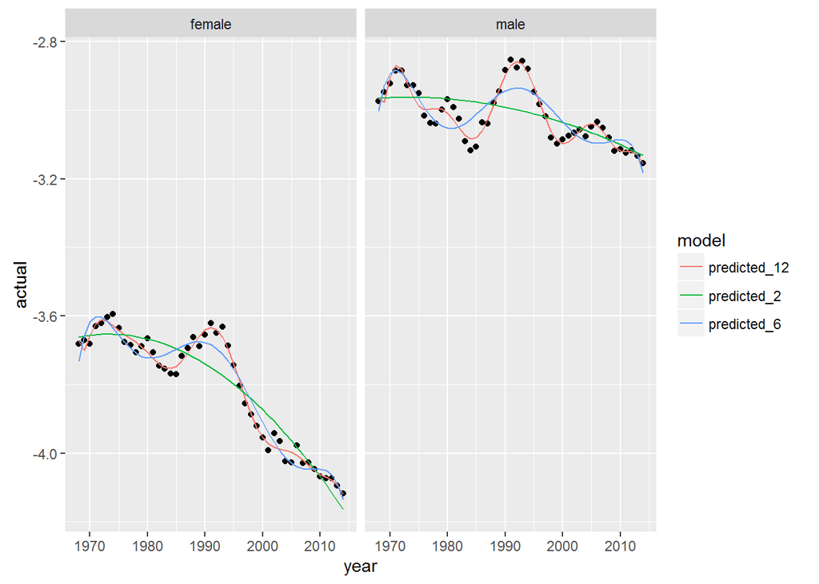

```r
comparisons <- simple %>%
  select(year, sex, actual = lg10mr)

comparisons$predicted_2 <- fit_poly2$fitted.values
comparisons$predicted_6 <- fit_poly6$fitted.values
comparisons$predicted_12 <- fit_poly12$fitted.values

comparisons <- comparisons %>% gather(model, prediction, predicted_2, predicted_6, predicted_12)

comparisons %>%
  ggplot(., aes(x = year))  +
  geom_point(aes(y = actual)) +
  geom_line(aes(y = prediction, group = model, colour = model)) +
  facet_wrap(~ sex)
```

We can see from the above that the 12th order polynomial has a close fit to the data, including possible four year cycles in the rates which may be indicative of the electoral cycle influencing the trends. This intuition is explored further in the following exercise